# R Package development with R-studio (and devtools)

Natàlia Vilor-Tejedor (natalia.vilortejedor@crg.eu)

# 1 Introduction

Building a package in R can be a tedious venture, depending on the number of functions and the complexity of the whole package.

If the authors’ intention is to make the package publicly available, the two standard repositories for R packages are:

- CRAN (http://cran.r-project.org) and,
- Bioconductor (http://www.bioconductor.org).

Helpful informations on all important steps of building an R package can be found in the R extension manual (http://cran.r-project.org/doc/manuals/R-exts.html).

Notice that, depending on the repository choice, the restrictions and the review process are different.

- For Bioconductor the package guidelines are more rigorous than elsewhere and are available at: http://bioconductor.org/developers/package-guidelines/.
- CRAN usually excepts packages that generally follow the R extension manual and that are not submitted as precompiled binaries (due to security reasons).

# 2 Getting started

To get started, make sure you also have the latest version of R (at least 3.5.0, which is the version that the code in this book uses), then run the following code to get the packages you’ll need:

```r
install.packages(c("devtools", "roxygen2", "testthat", "knitr"))
```

Make sure you have a recent version of RStudio. You can check you have the right version by running:

```r
install.packages("rstudioapi")
rstudioapi::isAvailable("x.xx.xxx")
```

If not, you may need to install the preview version from http://www.rstudio.com/.

This gives you access to the latest and greatest features, and only slightly increases your chances of finding a bug.

Use the following code to access new devtools functions:

```r
devtools::install_github("r-lib/devtools")
```

# 3 Package structure

A package is a convention for organizing files into directories. After writing some functions in your current `R` environment you can build a package automatically in R using the `package.skeleton()` function:

```r
rm(list=ls())
package.skeleton("package_name")
```

or, we can create a new package project with:

```r
devtools::create("path/package_name")
```

A folder named `package_name` should now be located in the current working directory.

## 3.1 Common structure of an `R` package:

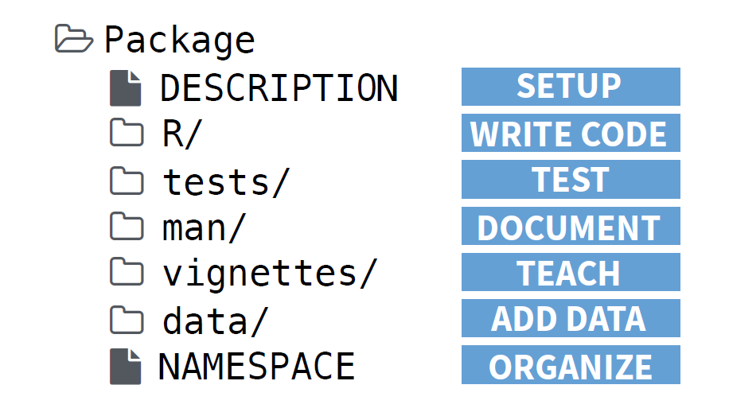

## 3.2 Description of the most common parts of an R package

### 3.2.1 Setup DESCRIPTION file

- `DESCRIPTION` [Required] : file with a description of the package, sets up how your package will work with other packages (dependencies), author(s) information, license, maintainer, etc.

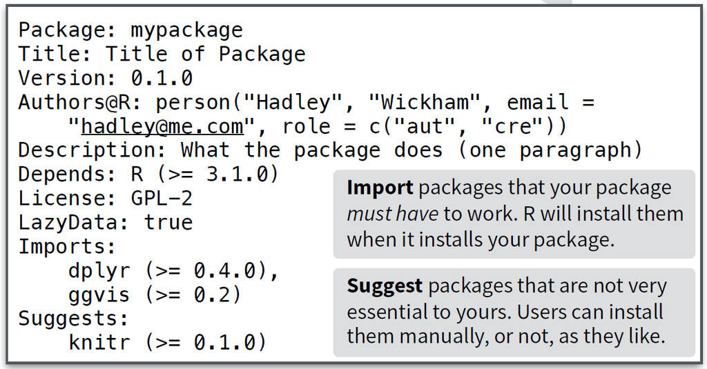

### 3.2.2 Write code (R/ folder)

- `R/` [Required] : folder with the functions of the package. All of the R code in your package goes in this folder. A package with just and R/ directory is still a very useful package.

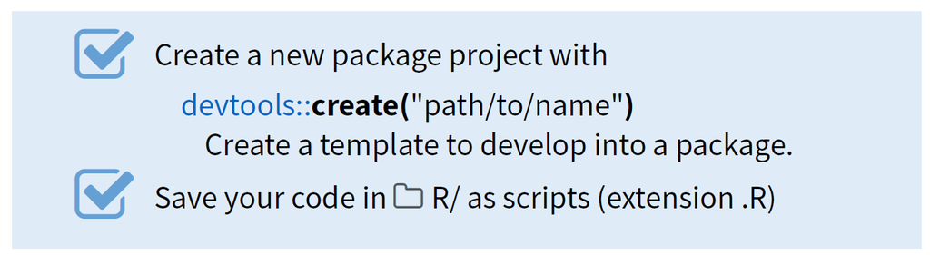

### 3.2.3 Tests

- In `tests/` [optional], we can store tests that will alert you if your code breaks.

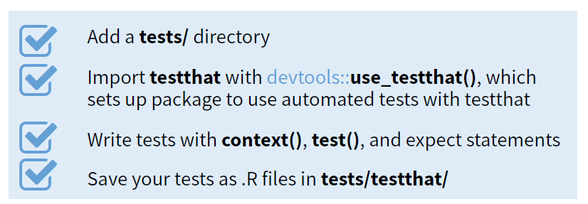

- Statements:

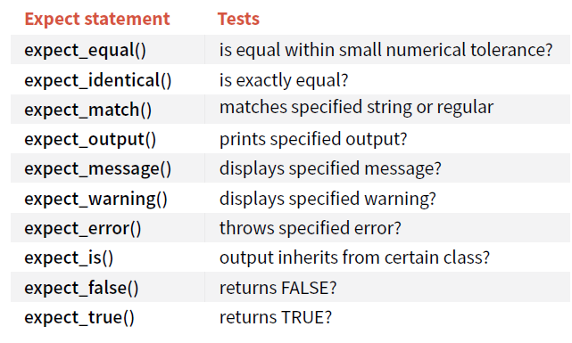

- Example:

```r
context("Arithmetic")

test_that("Math works", {
  expect_equal(1 + 1, 2)
  expect_equal(1 + 2, 3)
  expect_equal(1 + 3, 4)
})
```

### 3.2.4 man/ directory

- `man/` [Required] : contains the documentation for your functions, the help pages in your package.

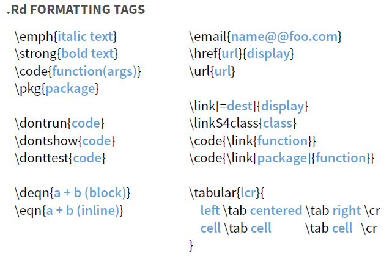

### 3.2.5 data/ directory

- `data/` [optional] directory allows you to include data in your package. (Suggestion: Save data as `.Rdata` files).

### 3.2.6 NAMESPACE

- `NAMESPACE` [Required] file helps you make your package selfcontained: making it accessible for other packages, and also for importing other packages or functions from other packages that are used insight this package.

### 3.2.7 README file

- `README`: file with additional information about the package or changes since the last version of the package

## 3.3 Alternative:

By default, if you have at least one function and one `R` object in your current environment, the `package.skeleton()` function is creating the `DESCRIPTION` file and the folders `R`, `man` and `data`.

Notice that we can directly create our new package from the toolbar of Rstudio:

[figure not shown]

## 3.4 Hands on

```r
IC.z.test <- function(x, sigma, conf.level=0.95) {
  alpha <- 1 - conf.level
  z.alpha <- qnorm(1-alpha/2)
  n <- length(x)
  SE <- sigma/sqrt(n)
  return(mean(x) + c(-1,1)*z.alpha*SE)
}

z.test <- function(x, mu=0, sigma=1){
  n <- length(x)
  SE <- sigma/sqrt(n)
  z <- (mean(x)-mu)/SE
  p.value <- (1-pnorm(abs(z)))*2
  return(list(media=mean(x), z=z, p.valor=p.value))
}

package.skeleton("my_first_package")
```

> Inspect contents (files and subfolders) of the generated package.